# mth_416_H2_ak

H2

Exercise 1.

**see problem**

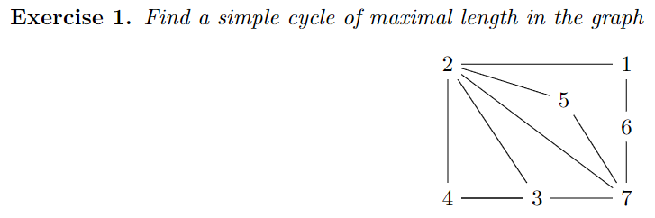

A simple cycle does not have repeating vertecies (aside from the start/finish).

The cycle $2437612$ is the longest, computed numerically using the networkx package below

```
[[2, 4, 3], [2, 4, 3, 7], [2, 4, 3, 7, 5], [2, 4, 3, 7, 6, 1], [2, 1, 6, 7], [2, 1, 6, 7, 3], [2, 1, 6, 7, 5], [2, 7, 3], [2, 7, 5], [2, 3, 7, 5]]
[2, 4, 3, 7, 6, 1]
```

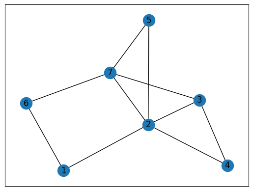

```python
import networkx as nx
E = {(1,2),(1,6),(2,5),(2,7),(2,3),(2,4),(4,3),(3,7),(5,7),(6,7)}
G = nx.Graph(E)
nx.draw_networkx(G, with_labels = True)

print([cycle for cycle in nx.simple_cycles(G)])

a = sorted(list(nx.simple_cycles(G)), key = lambda s: -len(s))
print(a[0])
```

This result makes logical sense. To make a cycle that includes all points, either the node $7$ or $2$ must be hit twice since $61$, $34$ and $5$ are all connected only by $7$ and $2$.

Exercise 2.

**see problem**

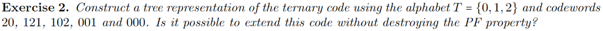

A quick test is to check if the Kraft-McMillan number is less than $1$.

$$ K = 0 + 0 + \frac{1}{9} + \frac{4}{27} = \frac{7}{27} = 0.259 $$

Since $K<1$, the PF code can be extended without losing the PF property.

An even quicker test would be to give an example of such a code. $111$ can be added since $11$ and $1$ are not codewords

Exercise 3.

**see problem**

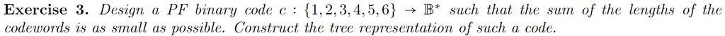

Using length one, only $2^1=2$ values can be used, but $2^3=8$ can be represented with length 3 codewords.

One arrangement is $$ C = (000, 001, 010, 011, 100, 101) $$ The sum of length is $6*3=18$, can this be less? Let's look at the tree.

```python
import networkx as nx
from other_code import make_edges_from_code, hierarchy_pos
```

```python
num_layers = 3

code = {
    '000':'[1]',
    '001':'[2]',
    '010':'[3]',
    '011':'[4]',
    '100':'[5]',
    '101':'[6]'
    }

connections, layers = make_edges_from_code(code, num_layers=3)
```

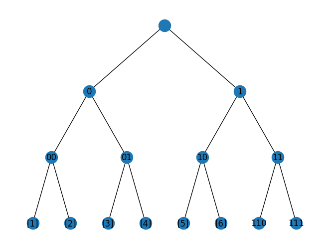

```python
G=nx.Graph()
G.add_edges_from(connections)
pos = hierarchy_pos(G,'')

nx.draw(G, pos=pos, with_labels=True)
```

We can map $5$ and $6$ to the codewords $10$ and $11$ to make the result shorter

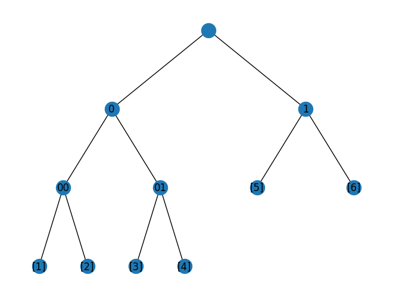

```python
num_layers = 3

code = {
    '000':'[1]',
    '001':'[2]',
    '010':'[3]',
    '011':'[4]',
    '10':'[5]',
    '11':'[6]'
    }

connections, layers = make_edges_from_code(code, num_layers)

G=nx.Graph()
G.add_edges_from(connections)
pos = hierarchy_pos(G,'')

nx.draw(G, pos=pos, with_labels=True)
```

This is prefix free and has length

$$2*2+4*3=16$$

Exercise 4.

**see problem**

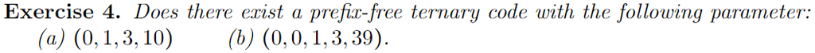

Theorem 2.3.5. Let $b ∈ Z^+$ and $M ∈ N$. Let $n = (n_0,n_1,...,n_M)$ be a tuple of non-negative integers such that $K ≤ 1$, where $K$ is the Kraft-McMillan number of the parameter $n$ to the base $b$. Then there exists a $b$-nary PF code $C$ with parameter $n$

Using theorem 2.3.5, we need only calculate the Kraft-Mcmillan Number

$$ K_a = 0 + \frac{1}{3} + \frac{3}{9} + \frac{10}{27} = 28/27 > 1 \\ K_b = 0 + 0 + \frac{1}{9} + \frac{3}{27} + \frac{39}{81} = \frac{57}{81} < 1 $$ Thus parameter a does not have a prefix-free code, while parameter b does

Exercise 5.

**see problem**

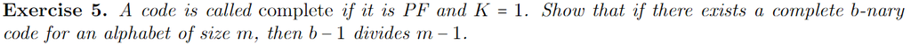

example: see exercise 3.

Codewords: $\{10, 11, 000, 001, 010, 011 \}$
Parameter: $(0, 0, 2, 4)$
Kraft-Mcmillan: $$ K = 0 + \frac{0}{2} + \frac{2}{4} + \frac{4}{8} = 1 $$

This code is complete. Alphabet size $6$, and trivially divides evenly $$ \frac{6-1}{2-1}=5 $$

We will proove that for a complete $b$-nary code, the encoded alphabet of size $m$ has the feature $m - 1 = 0 \pmod{b-1}$

b-nary code: $|T|=b$  
alphabet of size m: $|S^n|=m$

Before continuing, note that this does not hold for $b=1$, and is trivial for $b=2$, since any value of $m-1$ is divisible by one. We will consider cases where $b>2$

Since $C: S^n \mapsto T^*$ exists and $K=1$,

$$ K = \sum_i^M\frac{n_i}{b^i} = 1 \\ $$ Where $M$ is the longest codeword in $C$, which exists since the alphabet being encoded has a finite size and $C$ is 1-to-1.
Then

$$ m = \sum_i^M n_i $$ and $$ b^M\sum_i^M\frac{n_i}{b^i} = b^M \\ \sum_i^M n_ib^{M-i} = b^M $$

Since $b = 1 \pmod{b-1}$ and $b^k = 1 \pmod{b-1}$ for positive integers of $k$, this equates to

$$ \sum_i^M n_i = 1 \pmod{b-1} \\ m = 1 \pmod{b-1} \\ m-1 = 0\pmod{b-1} $$ Thus $m-1$ divides by $b-1$ with a remainder of zero

Exercise 6.

**see problem**

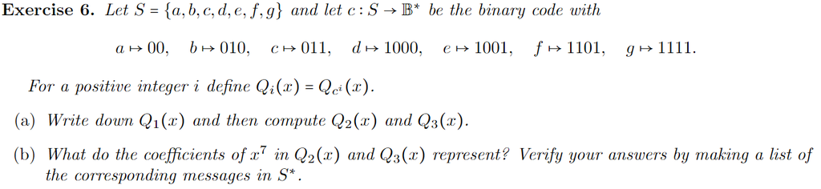

6. The parameter for $c$ is

$$ (0,0,1,2,4) $$

(a) $$ Q_1(x) = x^2 + 2x^3 + 4x^4 \\ Q_2(x) = x^4 + 4x^5 + 12 x^6 + 16x^7 + 16x^8 \\ Q_3(x) = x^6 + 6x^7 + 24x^8 + 56x^9 + 96 x^{10} + 96 x^{11} + 64 x^{12} $$

(b) The coefficients of $x^7$ represent how many codewords of $CC$ and $CCC$ (aka $C^3$) have length $7$.

```python
code = {
    'a':'00',
    'b':'010',
    'c':'011',
    'd':'1000',
    'e':'1001',
    'f':'1101',
    'g':'1111'
}

q2 = set()
q3 = set()

for c1 in code.keys():
    for c2 in code.keys():
        if len(code[c1]+code[c2]) == 7:
            q2.add(c1+c2)

        for c3 in code.keys():
            if len(code[c1]+code[c2]+code[c3]) == 7:
                q3.add(c1+c2+c3)

print(q2)
print(q3)
```

```
{'db', 'ec', 'bf', 'cf', 'fb', 'gb', 'gc', 'ce', 'fc', 'cg', 'dc', 'cd', 'bd', 'be', 'bg', 'eb'}
{'aca', 'aab', 'baa', 'caa', 'aba', 'aac'}
```